# AI og rødder i andengradspolynomier

B-niveau

Et andengradspolynomium kan have enten ingen, én eller to rødder – og måske kan du ligefrem huske en metode til at bestemme antallet af rødder. Men kan man mon bruge kunstig intelligens til at bestemme antallet af rødder i et andengradspolynomium? Det vil vi undersøge i dette forløb.

**Forudsætninger og tidsforbrug**

Forløbet kræver kendskab til:

- Rette linjer.
- Andengradspolynomier og rødder.

**Tidsforbrug:** Ca. 90 minutter.

Vi anbefaler, at I i dette forløb arbejder i grupper på 3-4 elever.

## Andengradspolynomier og rødder

Lad os lige starte med at minde om, at et andengradspolynomium er en funktion med en forskrift på formen
$$f(x)=ax^2 + bx + c, \quad a \neq 0$$
Grafen for et andengradspolynomium kaldes som bekendt for en *parabel*. I figur 1 ses tre eksempler på sådanne parabler.

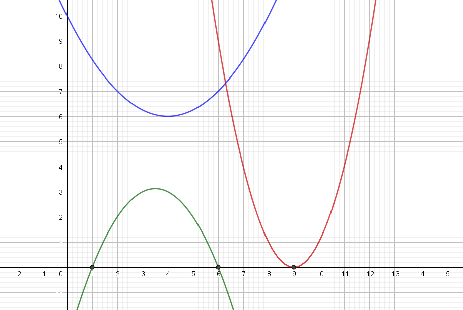

Figur 1: Graferne for tre forskellige andengradspolynomier.

Hvis vi løser andengradsligningen
$$f(x)=ax^2 + bx + c=0$$
finder vi andengradspolynomiets rødder. Men at løse $f(x)=0$, svarer netop til at bestemme, hvor den tilhørende parabel skærer $x$-aksen. I figur 1 kan vi se, at den grønne parabel skærer $x$-aksen to steder. Det vil sige, at det tilhørende andengradspolynomium har to rødder. Den røde parabel skærer $x$-aksen ét sted – det tilhørende andengradspolynomium har altså én rod. Endelig kan vi se, at den blå parabel slet ikke skærer $x$-aksen, og det tilhørende andengradspolynomium har derfor ingen rødder.

Du husker nok, hvordan man bestemmer antallet af rødder i et andengradspolynomium. Vi har brug for diskriminanten $d$:

$$d = b^2-4ac
\tag{1}$$

Og der gælder så, at
$$\begin{aligned}
&d<0: \quad f \text{ har ingen rødder} \\
&d=0: \quad f \text{ har én rod} \\
&d>0: \quad f \text{ har to rødder} \\
\end{aligned}$$

Idéen er nu at undersøge, om vi kan bruge kunstig intelligens til at afgøre[^1], om et andengradspolynomium overhovedet har nogle rødder alene ude fra de tre koefficienter $a$, $b$ og $c$ – og helt uden at kende noget til diskriminantformlen i (1)!

<sup>1</sup> Det er klart, at der er intet nyt under solen her. Vi kan jo bare selv beregne diskriminanten og svare på spørgsmålet. Men formålet er her at lære lidt om, hvad det vil sige at bruge kunstig intelligens i et tilfælde, hvor vi allerede selv kender svaret. Desuden findes der ingen lukkede løsningsformler for at bestemme rødder i et polynomium, så snart graden af polynomiet er $5$ eller derover. Så idéen kan generaliseres, og så er den måske slet ikke så tosset endda!

Inden vi går i gang, vil vi starte med at indse, at i stedet for at løse ligningen

$$a x^2 + bx +c = 0
\tag{2}$$

Så kan vi lige så godt løse en ligning på formen

$$x^2 + bx +c =0$$
hvor altså $a=1$. Det virker måske som en forsimpling, men da vi har antaget, at $a \neq 0,$ så kan vi i ligningen i (2) dividere igennem med $a$ og få

$$\begin{aligned}
\frac{a}{a} x^2 + \frac{b}{a} x + \frac{c}{a} &= \frac{0}{a} \quad \Leftrightarrow \\
x^2 + \frac{b}{a} x + \frac{c}{a} &= 0
\end{aligned}$$

Det betyder, at når vi skal bestemme rødder i andengradspolynomier, så er det tilstrækkeligt, at betragte andengradspolynomier med en forskrift på formen

$$f(x)=x^2+bx+c$$
fordi man simpelthen bare tager sit oprindelige andengradspolynomium og dividerer igennem med $a$. Lad os illustrere det med et eksempel.

**Eksempel 1** Betragt andengradspolynomiet med forskriften

$$f(x)=-4x^2+8x+12$$
Her har vi $a=-4, b=8$ og $c=12$. Løser vi ligningen $f(x)=0$, finder vi ud af, at $f$ har to rødder nemlig $-1$ og $3$. Dividerer vi forskriften for $f$ igennem med $a=-4$ fås et nyt andengradspolynomium $g$ med forskrift

$$g(x)=x^2-2x-3$$
Her er koefficienterne $a=1, b=-2$ og $c=-3$. Men $g$ har præcis samme rødder som $f$ – nemlig $-1$ og $3$. Dette ses også illustreret i figur 2, hvor grafen for $f$ og $g$ begge skærer $x$-aksen i $-1$ og $3$.

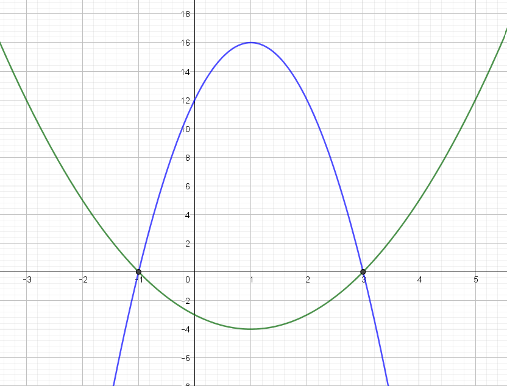

Figur 2: Grafen for $f(x)=-4x^2+8x+12$ (den blå) og $g(x)=x^2-2x-3$ (den grønne), som begge skærer $x$-aksen samme sted. Det vil sige, at $f$ og $g$ har de samme rødder. I dette tilfælde $-1$ og $3$.

## Træningsdata

I dette eksempel vil vi nøjes med at se på, om vi kan bruge en metode fra kunstig intelligens, så vi forhåbentlig kan få svar på, om et givent andengradspolynomium enten har *ingen* eller *en eller to* rødder. Vi vil altså gerne finde en metode, som for en given parabel kan svare på, om parablen skærer $x$-aksen eller ej (og altså ikke hvor mange gange den eventuelt skærer $x$-aksen).

**Opgave 1: Rødder eller ej?**

Overvej følgende:

- Hvordan laver man et andengradspolynomium, der har én eller to rødder?
- Hvordan laver man et andengradspolynomium, som ingen rødder har?

For at bruge kunstig intelligens skal vi have lavet en masse eksempler på forskellige andengradspolynomier (det vil her sige med forskellige værdier af $b$ og $c$) samtidig med, at vi også finder ud af, om det tilhørende andengradspolynomium har rødder eller ej. Den værdi, der angiver om et polynomium har rødder eller ej, kalder man for en *targetværdi*. Tænk på det som en lille label du sætter på hvert eksempel, hvor du fortæller, hvad det rigtige svar er – *“det er altså det her, jeg gerne vil have, at du lærer!”*. Samlet set kalder man de forskellige eksempler inklusiv targetværdien for *træningsdata*.

**Opgave 2: Træningsdata**

Alle i gruppen skal nu:

1. Finde et andengradspolynomium som ikke har nogle rødder (husk at $a=1$). Notér din værdi af $b$ og $c$ og sæt her targetværdien $t$ til $-1$.
2. Finde et andengradspolynomium som har én eller to rødder (husk at $a=1$). Notér din værdi af $b$ og $c$ og sæt her targetværdien $t$ til $1$.

I skal nu indsætte jeres forskellige værdier for $b, c$ og $t$ i et regneark. I videoen herunder er det vist, hvordan man gør i GeoGebra:

[video not shown]

Disse data er nu præcis det, man kalder for *træningsdata*.

- Indtast jeres værdier i et regnark, som det er vist i videoen.
- Indtegn dine værdier af $b$ og $c$ i et koordinatsystem, hvor værdien af $b$ er på $x$-aksen, og værdien af $c$ er på $y$-aksen. Hvis $(b,c)$-punktet svarer til et andegradspolynomium, som har rødder, farves punktet rødt og ellers farves det blåt. Dette er også vist i videoen ovenfor.

## Træning af kunstig intelligens

En simpel metode inden for kunstig intelligens er at prøve at bestemme en ret linje, som kan bruges til at adskille de røde punkter fra de blå punkter i det punktplot, som I har lavet i opgave 2.

Hvis man skal have en computer til at gøre det, så vil man typisk starte med en hel tilfældig ret linje med en ligning på formen

$$y=a \cdot x+b$$

og så prøve at opdatere hældningen $a$ og skæring med $y$-aksen $b$, sådan at linjen bliver bedre og bedre til at adskille de røde punkter fra de blå.

Nu ser vi jo på andengradspolynomier med en forskrift på formen $f(x)=x^2+bx+c$. Det vil sige, at $b$ allerede har en betydning. Derfor er det ikke så hensigtsmæssigt at bruge $b$ igen i ligningen for en ret linje. Derfor vælger vi her at beskrive den rette linje med en ligning på formen

$$y = w_1 \cdot x + w_0$$
Det vil altså sige, at $w_1$ er linjens hældning, og $w_0$ er linjens skæring med $y$-aksen.

**Opgave 3: Bestemmelse af en linje som kan adskille de røde punkter fra de blå**

- I inputfeltet i GeoGebra skal du taste: `y=w1*x+w0`.
- Når GeoGebra spørger, om du vil oprette skydere for `w0` og `w1`, svarer du "Opret skydere".
- Træk i skyderne for `w0` og `w1` og prøv om du kan finde en ret linje, som kan adskille de røde punkter fra de blå.

**Opgave 4: Flere træningsdata**

- Afgør om følgende andengradspolynomier har rødder og tilføj dem til dit træningsdata (husk ingen rødder svarer til at $t=-1$ og det tilhørende punkt farves blåt, mens én eller to rødder svarer til $t=1$ og punktet farves rødt):

$$\begin{aligned}
f_1(x) &= x^2 + 10x + 26 \\
f_2(x) &= x^2 + 10x + 24\\
f_3(x) &= x^2 + 5x + 6\\
f_4(x) &= x^2 + 5x + 7 \\
f_5(x) &= x^2 + 2x + 1\\
f_6(x) &= x^2 + 2x + 2 \\
\end{aligned}$$

- Kan det lade sig gøre at adskille de to grupper med den rette linje, du fandt i opgave 3?
- Hvis ikke kan du så bestemme en ny ret linje, som kan adskille de røde punkter fra de blå?

Som du netop har opdaget, er det en umulig opgave, vi har givet os selv! Vi kan ikke finde en ret linje, som i alle tilfælde kan bruges til at adskille de røde punkter fra de blå. 😕

Lad os se på hvorfor. Som tidligere nævnt har vores linje en ligning på formen

$$y=w_1 \cdot x + w_0$$

Men nu har vi $b$-værdier ud af $x$-aksen og $c$-værdier op af $y$-aksen, så i virkeligheden ser ligningen sådan her ud:

$$c=w_1 \cdot b + w_0
\tag{3}$$

hvor $b$ og $c$ jo svarer til koefficinter i forskellige andengradspolymonier med forskrift $f(x)=x^2+bx+c$.

Vi husker nu på formlen for diskriminanten $d=b^2-4ac=b^2-4c$, da $a=1$ i vores eksempel. Skillelinjen for om andengradspolynomiet har ingen eller flere rødder, går netop ved $d=0$. Det vil sige

$$b^2-4c =0
\tag{4}$$

som kan omskrives til

$$c = \frac{1}{4}b^2
\tag{5}$$

Men vi kan ikke finde nogle værdier af $w_0$ og $w_1$, så udtrykket i (3) kommer til at svare til udtrykket i (5). Det er fordi, at i (3) indgår der kun et $b$, mens der i (5) indgår et $b^2$. Denne observation giver os imidlertid også en løsning på vores problem. I stedet for at lade træningsdata bestå af $b$- og $c$-værdier, så vil vi i stedet lade træningsdata bestå af $b^2$- og $c$-værdier! Det vil sige, at vi ud af $x$-aksen vil afsætte $b^2$ og op af $y$-aksen, vil vi afsætte $c.$

**Opgave 5: Transformerede træningsdata**

- Brug dit regneark fra tidligere og udregn $b^2$.
- Indtegn dine værdier af $b^2$ og $c$ i et nyt koordinatsystem, hvor værdien af $b^2$ er på $x$-aksen, og værdien af $c$ er på $y$-aksen. Hvis $(b^2,c)$-punktet svarer til et andegradspolynomium, som har rødder, farves punktet rødt og ellers farves det blåt.
- Hvilken linje kan du vælge til at adskille de to grupper?

Idéen med at prøve at adskille to grupper af punkter med en ret linje bruges i den AI-metode som kaldes for perceptroner.

Hvis du vil prøve at bruge den metode på dine data om andengradspolynomier, kan du gøre det [her](https://apps01.math.aau.dk/adaline/).